# Exercice B

```python
import pandas as pd
import numpy as np
from matplotlib import pyplot as plt
from statsmodels.graphics.tsaplots import plot_acf
from statsmodels.graphics.tsaplots import plot_pacf
from statsmodels.stats.diagnostic import acorr_ljungbox

from statsmodels.tsa.arima_model import ARMA
from sklearn.metrics import mean_squared_error
from statsmodels.tsa.stattools import acf,pacf
from scipy import stats
```

```python
df_useconomics = pd.read_csv('useconomis.csv')
df_useconomics['M1'] = np.log(df_useconomics['M1'])
df_useconomics['gnp'] = np.log(df_useconomics['gnp'])
df_useconomics.columns=['log(M1)','log(gnp)','rd','rb']
logPNB = np.log(df_useconomics['log(gnp)'])
df_useconomics.head(15)
```

|  | log(M1) | log(gnp) | rd | rb |
| --- | --- | --- | --- | --- |
| 0 | 6.111246 | 7.249073 | 0.010800 | 0.026133 |
| 1 | 6.115892 | 7.245084 | 0.008133 | 0.025233 |
| 2 | 6.129268 | 7.257003 | 0.008700 | 0.024900 |
| 3 | 6.141177 | 7.271565 | 0.010367 | 0.025667 |
| 4 | 6.151881 | 7.292746 | 0.012600 | 0.027467 |
| 5 | 6.159307 | 7.303641 | 0.015133 | 0.028167 |
| 6 | 6.162472 | 7.316880 | 0.018633 | 0.029267 |
| 7 | 6.161840 | 7.325610 | 0.023467 | 0.028900 |
| 8 | 6.164157 | 7.323633 | 0.023800 | 0.028867 |
| 9 | 6.158884 | 7.328175 | 0.025967 | 0.029900 |
| 10 | 6.149963 | 7.328897 | 0.025967 | 0.031267 |
| 11 | 6.147399 | 7.339927 | 0.030633 | 0.033000 |
| 12 | 6.141392 | 7.348137 | 0.031700 | 0.032733 |
| 13 | 6.133832 | 7.347557 | 0.031567 | 0.034333 |
| 14 | 6.124902 | 7.353402 | 0.033800 | 0.036300 |

### Question 1

```python
def build_diff(df):

  diff = np.zeros(df.shape[0]-1)

  for i in range (1,len(diff)):

    diff[i-1] = df.iloc[i]-df.iloc[i-1]


  return diff

DiffPNB = build_diff(logPNB)
DiffPNB = pd.DataFrame(DiffPNB)
DiffPNB.columns = ['Différence']
DiffPNB.head()
```

|  | Différence |
| --- | --- |
| 0 | -0.000550 |
| 1 | 0.001644 |
| 2 | 0.002005 |
| 3 | 0.002909 |
| 4 | 0.001493 |

Ces valeurs représentent la différence entre chaque trimestre

### Question 2

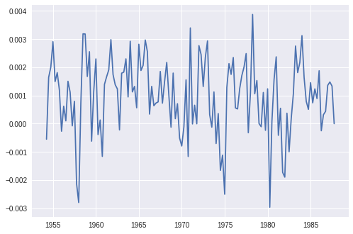

```python
sequence = np.linspace(1954.25, 1987.75, 135, endpoint=True)
plt.plot(sequence,DiffPNB)
```

### Question 3

```python
mean = np.mean(DiffPNB)

print("mean :",mean[0])

from scipy import stats

stats.ttest_ind(DiffPNB,np.zeros(DiffPNB.shape[0]))
```

```
mean : 0.0009668602428301229
```

```
Ttest_indResult(statistic=array([8.55311249]), pvalue=array([9.34366673e-16]))
```

On remarque une léger décallage de la moyenne qui est légèrement décentrée

### Question 4

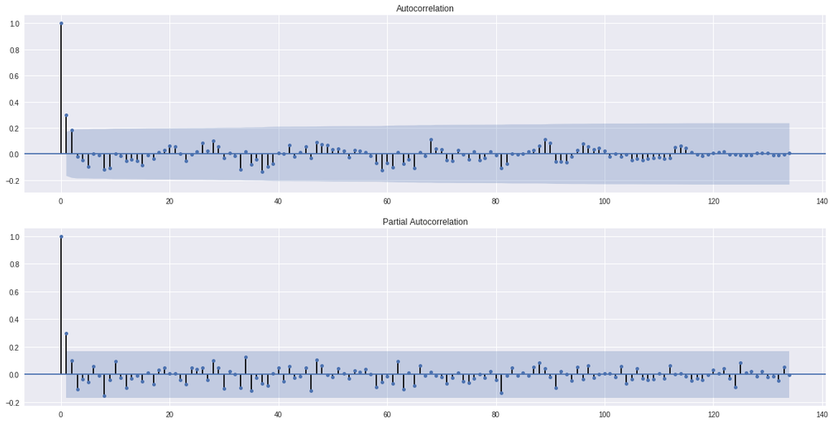

```python
plt.figure(figsize=(20,10))
plt.subplot(211)
plot_acf(DiffPNB, ax=plt.gca())
plt.subplot(212)
plot_pacf(DiffPNB, ax=plt.gca())
plt.show()
```

Valeurs possibles pour MA : 0,1,2

Valeurs possibles pour AR : 0,1,8

### Question 5

```
                              ARMA Model Results
==============================================================================
Dep. Variable:                      y   No. Observations:                  134
Model:                     ARMA(0, 2)   Log Likelihood                 706.896
Method:                       css-mle   S.D. of innovations              0.001
Date:                Thu, 20 Dec 2018   AIC                          -1405.792
Time:                        09:24:18   BIC                          -1394.200
Sample:                             0   HQIC                         -1401.081

==============================================================================
                 coef    std err          z      P>|z|      [0.025      0.975]
------------------------------------------------------------------------------
const          0.0010      0.000      6.187      0.000       0.001       0.001
ma.L1.y        0.2735      0.085      3.207      0.002       0.106       0.441
ma.L2.y        0.1975      0.080      2.482      0.014       0.042       0.354
                                    Roots
=============================================================================
                 Real           Imaginary           Modulus         Frequency
-----------------------------------------------------------------------------
MA.1           -0.6923           -2.1410j            2.2501           -0.2998
MA.2           -0.6923           +2.1410j            2.2501            0.2998
-----------------------------------------------------------------------------
```

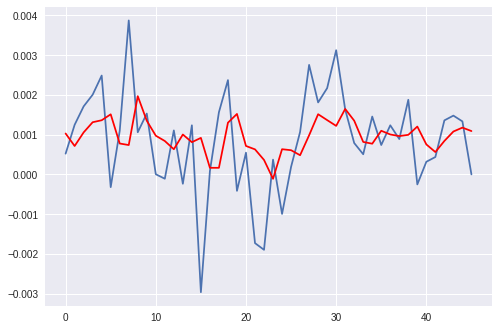

```
                              ARMA Model Results
==============================================================================
Dep. Variable:                      y   No. Observations:                  134
Model:                     ARMA(0, 1)   Log Likelihood                 704.105
Method:                       css-mle   S.D. of innovations              0.001
Date:                Thu, 20 Dec 2018   AIC                          -1402.210
Time:                        09:24:21   BIC                          -1393.517
Sample:                             0   HQIC                         -1398.678

==============================================================================
                 coef    std err          z      P>|z|      [0.025      0.975]
------------------------------------------------------------------------------
const          0.0010      0.000      7.241      0.000       0.001       0.001
ma.L1.y        0.2309      0.071      3.254      0.001       0.092       0.370
                                    Roots
=============================================================================
                 Real           Imaginary           Modulus         Frequency
-----------------------------------------------------------------------------
MA.1           -4.3317           +0.0000j            4.3317            0.5000
-----------------------------------------------------------------------------
```

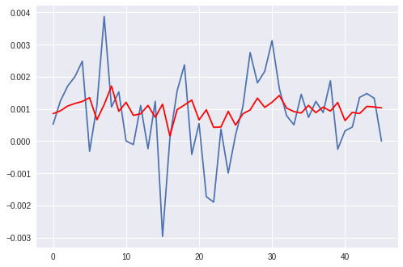

```
                              ARMA Model Results
==============================================================================
Dep. Variable:                      y   No. Observations:                  134
Model:                     ARMA(0, 8)   Log Likelihood                 709.415
Method:                       css-mle   S.D. of innovations              0.001
Date:                Thu, 20 Dec 2018   AIC                          -1398.830
Time:                        09:26:21   BIC                          -1369.852
Sample:                             0   HQIC                         -1387.054

==============================================================================
                 coef    std err          z      P>|z|      [0.025      0.975]
------------------------------------------------------------------------------
const          0.0010      0.000      6.963      0.000       0.001       0.001
ma.L1.y        0.2667      0.091      2.928      0.004       0.088       0.445
ma.L2.y        0.2530      0.091      2.770      0.006       0.074       0.432
ma.L3.y        0.0130      0.095      0.138      0.891      -0.173       0.199
ma.L4.y       -0.0798      0.098     -0.819      0.415      -0.271       0.111
ma.L5.y       -0.1432      0.100     -1.433      0.154      -0.339       0.053
ma.L6.y        0.0037      0.099      0.037      0.971      -0.191       0.199
ma.L7.y        0.0690      0.100      0.691      0.491      -0.127       0.265
ma.L8.y       -0.0574      0.093     -0.615      0.540      -0.240       0.125
                                    Roots
=============================================================================
                 Real           Imaginary           Modulus         Frequency
-----------------------------------------------------------------------------
MA.1           -1.4005           -0.0000j            1.4005           -0.5000
MA.2           -0.8891           -0.9071j            1.2701           -0.3734
MA.3           -0.8891           +0.9071j            1.2701            0.3734
MA.4            0.0932           -1.2040j            1.2076           -0.2377
MA.5            0.0932           +1.2040j            1.2076            0.2377
MA.6            1.5431           -0.0000j            1.5431           -0.0000
MA.7            1.3264           -1.2919j            1.8516           -0.1229
MA.8            1.3264           +1.2919j            1.8516            0.1229
-----------------------------------------------------------------------------
```

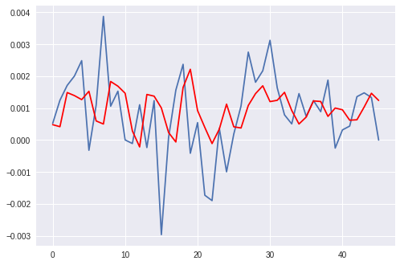

```
                              ARMA Model Results
==============================================================================
Dep. Variable:                      y   No. Observations:                  134
Model:                     ARMA(1, 0)   Log Likelihood                 705.649
Method:                       css-mle   S.D. of innovations              0.001
Date:                Thu, 20 Dec 2018   AIC                          -1405.297
Time:                        09:26:25   BIC                          -1396.604
Sample:                             0   HQIC                         -1401.765

==============================================================================
                 coef    std err          z      P>|z|      [0.025      0.975]
------------------------------------------------------------------------------
const          0.0010      0.000      6.300      0.000       0.001       0.001
ar.L1.y        0.3016      0.082      3.661      0.000       0.140       0.463
                                    Roots
=============================================================================
                 Real           Imaginary           Modulus         Frequency
-----------------------------------------------------------------------------
AR.1            3.3151           +0.0000j            3.3151            0.0000
-----------------------------------------------------------------------------
```

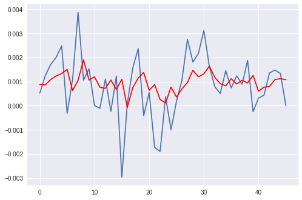

```
                              ARMA Model Results
==============================================================================
Dep. Variable:                      y   No. Observations:                  134
Model:                     ARMA(1, 1)   Log Likelihood                 706.012
Method:                       css-mle   S.D. of innovations              0.001
Date:                Thu, 20 Dec 2018   AIC                          -1404.024
Time:                        09:26:33   BIC                          -1392.433
Sample:                             0   HQIC                         -1399.314

==============================================================================
                 coef    std err          z      P>|z|      [0.025      0.975]
------------------------------------------------------------------------------
const          0.0010      0.000      5.895      0.000       0.001       0.001
ar.L1.y        0.4617      0.183      2.521      0.013       0.103       0.821
ma.L1.y       -0.1726      0.196     -0.883      0.379      -0.556       0.211
                                    Roots
=============================================================================
                 Real           Imaginary           Modulus         Frequency
-----------------------------------------------------------------------------
AR.1            2.1657           +0.0000j            2.1657            0.0000
MA.1            5.7933           +0.0000j            5.7933            0.0000
-----------------------------------------------------------------------------
```

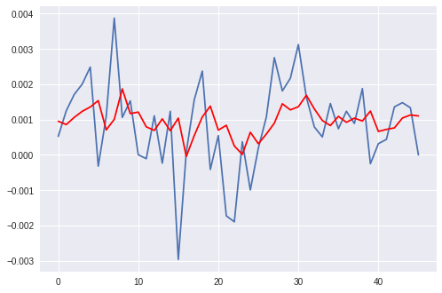

```
                              ARMA Model Results
==============================================================================
Dep. Variable:                      y   No. Observations:                  134
Model:                     ARMA(2, 0)   Log Likelihood                 706.319
Method:                       css-mle   S.D. of innovations              0.001
Date:                Thu, 20 Dec 2018   AIC                          -1404.638
Time:                        09:26:40   BIC                          -1393.047
Sample:                             0   HQIC                         -1399.928

==============================================================================
                 coef    std err          z      P>|z|      [0.025      0.975]
------------------------------------------------------------------------------
const          0.0010      0.000      5.714      0.000       0.001       0.001
ar.L1.y        0.2714      0.086      3.150      0.002       0.103       0.440
ar.L2.y        0.0999      0.086      1.161      0.248      -0.069       0.269
                                    Roots
=============================================================================
                 Real           Imaginary           Modulus         Frequency
-----------------------------------------------------------------------------
AR.1            2.0846           +0.0000j            2.0846            0.0000
AR.2           -4.8005           +0.0000j            4.8005            0.5000
-----------------------------------------------------------------------------
```

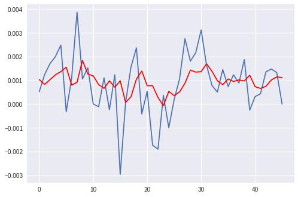

```
<statsmodels.tsa.arima_model.ARMAResultsWrapper at 0x7fe94ffe7e80>
```

```python
import warnings
warnings.filterwarnings('ignore')

X = DiffPNB.values

def test_model(p,q):

  size = int(len(X) * 0.66)
  train, test = X[0:size], X[size:len(X)]
  history = [x for x in train]
  predictions = list()
  for t in range(len(test)):
    model = ARMA(history, order=(p,q))
    model_fit = model.fit(disp=0)
    output = model_fit.forecast()
    yhat = output[0]
    predictions.append(yhat)
    obs = test[t]
    history.append(obs)
  error = mean_squared_error(test, predictions)

  print(model_fit.summary())
  plt.plot(test)
  plt.plot(predictions, color='red')
  plt.show()


  return model_fit

model_fit = test_model(0,2)
test_model(0,1)
test_model(0,8)
test_model(1,0)
test_model(1,1)
test_model(2,0)
```

- la fonction ARIMA renvoie : renvoie un ARIMA.result, qui lui même renvoie plusieurs parametres, obtenus en appelant différentes fonctions : interval de confiance, AIC, llh etc..

  (voir https://www.statsmodels.org/dev/generated/statsmodels.tsa.arima_model.ARIMAResults.html#statsmodels.tsa.arima_model.ARIMAResults)
- les coeffcients calculés pour un modèle ARMA sont : ρ et e θ (voir formules)
- log likelihood : Détermine la similarité d'une prediction avec des valeurs réelles. Les valeurs des paramètres sont trouvées de telle sorte qu'elles maximisent la probabilité que le processus décrit par le modèle produise les données qui ont été effectivement observées. On utilise le log pour simplifier les calculs.
- Akaike's Information Criterion : mesure de la qualité d'un modèle statistique. Plus il est bas, mieux est le modèle

### Question 6

```
                              ARMA Model Results
==============================================================================
Dep. Variable:                      y   No. Observations:                  134
Model:                     ARMA(0, 1)   Log Likelihood                 704.105
Method:                       css-mle   S.D. of innovations              0.001
Date:                Thu, 20 Dec 2018   AIC                          -1402.210
Time:                        10:11:43   BIC                          -1393.517
Sample:                             0   HQIC                         -1398.678

==============================================================================
                 coef    std err          z      P>|z|      [0.025      0.975]
------------------------------------------------------------------------------
const          0.0010      0.000      7.241      0.000       0.001       0.001
ma.L1.y        0.2309      0.071      3.254      0.001       0.092       0.370
                                    Roots
=============================================================================
                 Real           Imaginary           Modulus         Frequency
-----------------------------------------------------------------------------
MA.1           -4.3317           +0.0000j            4.3317            0.5000
-----------------------------------------------------------------------------
```

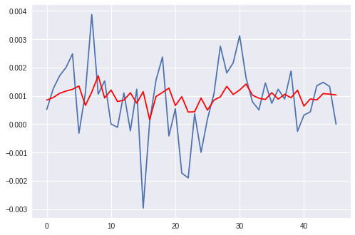

```
Box Test (pvalue) : 0.7612999640225664
Shapiro (pvalue) : 0.04102104529738426
```

```python
from statsmodels.stats.diagnostic import acorr_ljungbox

arma01 = test_model(0,1)
resid01 = arma01.resid

box = acorr_ljungbox(resid01,boxpierce=True)
shap = stats.shapiro(resid01)[1]
print('Box Test (pvalue) :', np.mean(box[3]) )
print('Shapiro (pvalue) :',shap )
```

```
                              ARMA Model Results
==============================================================================
Dep. Variable:                      y   No. Observations:                  134
Model:                     ARMA(0, 2)   Log Likelihood                 706.896
Method:                       css-mle   S.D. of innovations              0.001
Date:                Thu, 20 Dec 2018   AIC                          -1405.792
Time:                        10:11:40   BIC                          -1394.200
Sample:                             0   HQIC                         -1401.081

==============================================================================
                 coef    std err          z      P>|z|      [0.025      0.975]
------------------------------------------------------------------------------
const          0.0010      0.000      6.187      0.000       0.001       0.001
ma.L1.y        0.2735      0.085      3.207      0.002       0.106       0.441
ma.L2.y        0.1975      0.080      2.482      0.014       0.042       0.354
                                    Roots
=============================================================================
                 Real           Imaginary           Modulus         Frequency
-----------------------------------------------------------------------------
MA.1           -0.6923           -2.1410j            2.2501           -0.2998
MA.2           -0.6923           +2.1410j            2.2501            0.2998
-----------------------------------------------------------------------------
```

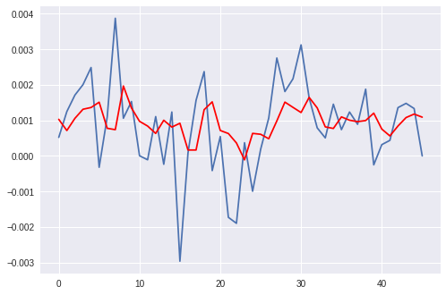

```
Box Test (pvalue) : 0.9549619803312307
Shapiro (pvalue) : 0.40737584233283997
```

```python
arma02 = test_model(0,2)
resid02 = arma02.resid

box = acorr_ljungbox(resid02,boxpierce=True)
shap = stats.shapiro(resid02)[1]
print('Box Test (pvalue) :', np.mean(box[3]) )
print('Shapiro (pvalue) :',shap)
```

```python
model = ARMA(DiffPNB.values, order=(8,2))
arma82  = model.fit(disp=0)

resid82 = arma82.resid

box = acorr_ljungbox(resid82,boxpierce=True)
shap = stats.shapiro(resid82)[1]
print('Box Test (pvalue) :', np.mean(box[3]) )
print('Shapiro (pvalue) :',shap)
```

```
Box Test (pvalue) : 0.9993601950717675
Shapiro (pvalue) : 0.27637773752212524
```

Pour deux des trois modèles ,on peut accepter l'hypothèse de la distribution normale de la série ( (8,2) et (0,2))

En ce qui concerne le test de Box-Pierce pour ces deux modèles les p-values sont vraiment très proche de 1. La répartition des résidus est aléatoire donc on peut considérer qu'il y a une très bonne stationnarité.

Notre dernier modèe (8,2) possède l’autocorrélation pour les différents décalages la plus faible ce qui nous amène à conclure que c'est le modèle le plus pertinent des trois.